# Project 4

Visualising data about videos from the YouTube channels Donut and Joshua Weissman

Amanullah Abdul Rahman

## Introduction

For this project, I decided to use Donut and [Joshua Weissman](https://www.youtube.com/@JoshuaWeissman) as my YouTube channels. This is because I like cars, cooking, and I’m subscribed to them. I wanted to create a visualisation comparing the videos to shorts, and I also wanted to create a graph on the number of comments to the length of the video title as I thougt maybe longer titles could be troll titles and would lead to more comments. In the end, I managed to create the second idea. The first idea had an issue where I did not know how to facet_wrap after creating the new table, so I decided to just create a joint “shorts vs videos” graph instead. I chose geom_bar and geom_cols for the plot 1 and 3 as they made sense to me and other geoms looked weird. I chose geom_point for plot 2 as it looked cool with the colours.

## Dynamic data story

With the data I collected from the YouTube API, I created the following dynamic data story:

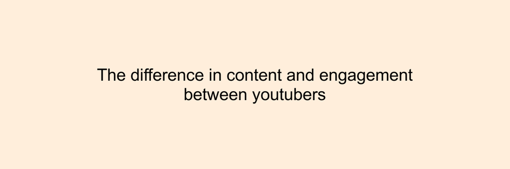

I believe the custom theme choice of my graphs show creativity. I chose light coloured backgrounds(matching link hover colour) and higher contrasting colours for the graphs themselves. I also removed the grid lines for a cleaner looking graph. The colours of the graph were selected to match the colour of the slides to look better, and to nicely contrast the html report as well.

## Learning reflection

One key idea I learnt from this module was how to create dynamic visualisations. This was basically the gif with the graphs of data I collected from YouTube. This was cool to learn as I can essentially create a mini slideshow of different data visualisations for anything I want. So if I wanted to create a visualisations for the number of job and internship rejections I have and will have, I just have to track it over time and eventually can create a gif of it, which will be cool to look at. It would be interesting to somehow collect data on all the videos as well as future videos automatically so I can then truly compare them against each other.

## Appendix

```r
library(tidyverse)

youtube_data <- read.csv("https://docs.google.com/spreadsheets/d/e/2PACX-1vRI8VDHH7vvWXwknbQ_ZfVRhjOb8SYTIleo0EaOqdiL6XZaDGmNN80V1_Ibbp6pPhnaNU-5fTxROeV7/pub?output=csv")


summarised_data <- youtube_data %>%
  mutate(video_type = ifelse(duration > 90, 'video','short')) %>%
  mutate(year = datePublished %>% str_sub(1,4) %>% parse_number())



data1 <- summarised_data %>%
  group_by(video_type) %>%
  summarise(n=n()) %>%
  ungroup()

my_theme <- theme(
  plot.background = element_rect(fill = "#FFEEDB"),
  panel.background = element_rect(fill = "#FFEEDB"),
  panel.grid = element_blank(),
  axis.ticks = element_line(),
  axis.line = element_line(),
  plot.margin = margin(1, 1, 1, 1, "cm")
)
#############################

# type of videos across both channels
type_of_video <- ggplot(data = data1) +
  geom_col(aes(x=video_type, y=n), fill = "#88498F") +
  my_theme +
  labs(title = "Overall Video Type",
       x="Video Type",
       y="Number of videos")
type_of_video

# title length vs comments
plot2 <- ggplot(data = summarised_data) +
  geom_point(aes(x=titleLength, y=commentCount, colour=video_type)) +
  my_theme +
  facet_wrap(vars(channelName)) +
  labs(title="Title Length vs Comments",
       x="Length of Title",
       y="Number of Comments",
       colour="Video Type")

# video type over time
plot3 <- ggplot(data = summarised_data) +
  geom_bar(aes(x=year, fill=video_type), position="dodge") +
  facet_wrap(vars(channelName)) +
  scale_x_continuous(breaks = seq(2014, 2024, 1)) +
  my_theme +
  labs(title="Variety Of Videos",
       x="Year Released",
       y="Number of videos",
       fill="Video Type")

ggsave("plot1.png", plot=type_of_video, width = 10, height = 7, units = "in")
ggsave("plot2.png", plot=plot2, width = 10, height = 7, units = "in")
ggsave("plot3.png", plot=plot3, width = 10, height = 7, units = "in")
```

```r
library(magick)

colours <- c("#fc746c","#06BAC1","#FFEEDB","#424874","#88498F")

blank <- image_blank(width=600, height=400, color = "#FFEEDB")

################################

text1 <- "The difference in content and engagement between youtubers" %>% str_wrap(40)

slide1 <- c(blank, blank) %>%
  image_append() %>%
  image_annotate(text=text1, size=40, gravity="center")

################################

text2 <- "Here we can see that the long form videos and short form short are produced in similar amounts" %>% str_wrap(40)
text2gif <- blank %>%
  image_annotate(text=text2, size=30, gravity="center")

plot1 <- image_read("plot1.png") %>%
  image_scale("600")

slide2 <- c(text2gif, plot1) %>%
  image_append()

################################

text3 <- "If we compared the length of the video title to the number of comments, we can see the difference in engagement between the youtubers as well" %>% str_wrap(40)
text3gif <- blank %>%
  image_annotate(text=text3, size=30, gravity="center")

plot2 <- image_read("plot2.png") %>%
  image_scale("600")

slide3 <- c(text3gif, plot2) %>%
  image_append()

################################
text4 <- "If we were to compare the number of videos released per year from the data we collected, we can see the API returned more videos for Donut, and more shorts for Joshua Weissman, which is interesting to see." %>% str_wrap(40)
text4gif <- blank %>%
  image_annotate(text=text4, size=30, gravity="center")

plot3 <- image_read("plot3.png") %>%
  image_scale("600")

slide4 <- c(text4gif, plot3) %>%
  image_append()

################################
text5 <- "Overall, I learned that Donut gets roughly the same comments for their videos, while Joshua got much more variety in comments, but they were for mainly shorts. This was interesting to see as both channels have similar subscriber numbers but Donut having 3 times more videos and shorts." %>% str_wrap(50)

slide5 <- c(blank, blank) %>%
  image_append() %>%
  image_annotate(text=text5, size=40, gravity="center")

frames <- c(rep(slide1, 8), rep(slide2, 8), rep(slide3, 8), rep(slide4, 8), rep(slide5, 8))
gif <- image_animate(frames, fps=1) %>%
  image_write("data_story.gif")
gif
```